# Introduction

The application is for merging two or more pdf files into the same file on Windows 10 OS. The application is written in Python using `tkinter` for the user interface and `PyPDF2` back-end. [Here is the link to the source code](https://github.com/longquangle/pdf_merger_source).

# Installation

### Step 1. Downloading

[Link to download](https://github.com/longquangle/pdf_merger_exe).

[figure not shown]

```python
from IPython.display import Image
Image(filename="download.png", width=500)
```

Download the file by clicking the green button **Download ZIP**.

### Step 2. Unzipping

Once the file is downloaded, unzip the file by right clicking on the downloaded file and choose **Extract All...** from the list of options.

Then, choose the desired location for the file.

The executable file is named `pdf_merger.exe` with a logo of a PDF as shown below.

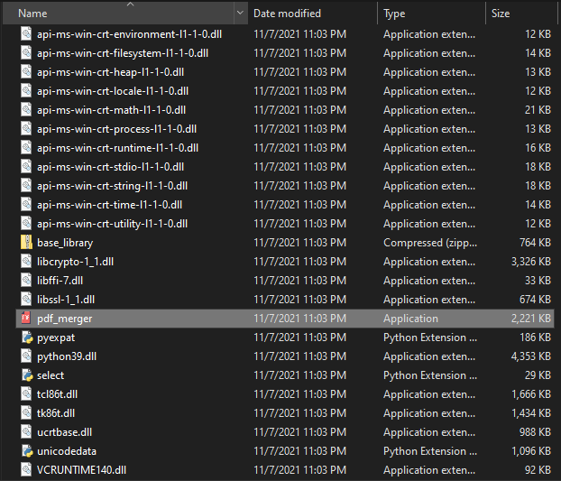

```python
Image(filename="exe_file.png", width=400)
```

### Step 3. Running the Application

Run the application by double clicking on the `pdf_merger.exe` file or **Open** the file.

A user GUI as below should pop up alongside the console.

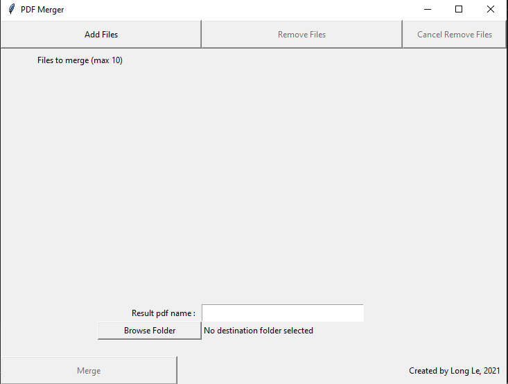

```python
Image(filename="application.png", width=550)
```

# Merging PDFs

### Step 1. Adding PDFs

Adding the PDFs to the application by clicking the **Add Files** button on the application. A window should pop up for the users to choose the PDFs.

*Note*: A maximum of 10 PDFs may be added at once.

### Step 2. Inputting the Name

Adding the name of the resulting PDF by inputting the name into the text box.

### Step 3 (Optional). Choosing the Destination Folder

Choosing the destination folder (path) by clicking **Browse Folder** button on the application.

*Note*: If no path is given, the resulting application will be at the application folder.

### Step 4. Merging Files

Merge all the selected files by clicking the **Merge** button.

### (Optional) Removing the Unwanted Files

Clicking **Remove Files**. Removing the file by clicking on the name of the file.

When done, click the **Cancel Remove Files** to get back to the application.